# Task 3 - Online Retail

(1) Packages

```python
import pandas as pd
import numpy as np
import matplotlib.pyplot as plt
import seaborn as sns
```

______________________________________________

(2) Data Preparation

```python
# Load Excel file
df = pd.read_excel("Online Retail.xlsx")

pd.reset_option('display.max_rows')
pd.reset_option('display.max_columns')

df
```

|  | InvoiceNo | StockCode | Description | Quantity | InvoiceDate | UnitPrice | CustomerID | Country |
| --- | --- | --- | --- | --- | --- | --- | --- | --- |
| 0 | 536365 | 85123A | WHITE HANGING HEART T-LIGHT HOLDER | 6 | 2010-12-01 08:26:00 | 2.55 | 17850.0 | United Kingdom |
| 1 | 536365 | 71053 | WHITE METAL LANTERN | 6 | 2010-12-01 08:26:00 | 3.39 | 17850.0 | United Kingdom |
| 2 | 536365 | 84406B | CREAM CUPID HEARTS COAT HANGER | 8 | 2010-12-01 08:26:00 | 2.75 | 17850.0 | United Kingdom |
| 3 | 536365 | 84029G | KNITTED UNION FLAG HOT WATER BOTTLE | 6 | 2010-12-01 08:26:00 | 3.39 | 17850.0 | United Kingdom |
| 4 | 536365 | 84029E | RED WOOLLY HOTTIE WHITE HEART. | 6 | 2010-12-01 08:26:00 | 3.39 | 17850.0 | United Kingdom |
| ... | ... | ... | ... | ... | ... | ... | ... | ... |
| 541904 | 581587 | 22613 | PACK OF 20 SPACEBOY NAPKINS | 12 | 2011-12-09 12:50:00 | 0.85 | 12680.0 | France |
| 541905 | 581587 | 22899 | CHILDREN'S APRON DOLLY GIRL | 6 | 2011-12-09 12:50:00 | 2.10 | 12680.0 | France |
| 541906 | 581587 | 23254 | CHILDRENS CUTLERY DOLLY GIRL | 4 | 2011-12-09 12:50:00 | 4.15 | 12680.0 | France |
| 541907 | 581587 | 23255 | CHILDRENS CUTLERY CIRCUS PARADE | 4 | 2011-12-09 12:50:00 | 4.15 | 12680.0 | France |
| 541908 | 581587 | 22138 | BAKING SET 9 PIECE RETROSPOT | 3 | 2011-12-09 12:50:00 | 4.95 | 12680.0 | France |

541909 rows × 8 columns

```python
# Basic info: column types, non-null values
df.info()
```

```
<class 'pandas.core.frame.DataFrame'>
RangeIndex: 541909 entries, 0 to 541908
Data columns (total 8 columns):
 #   Column       Non-Null Count   Dtype
---  ------       --------------   -----
 0   InvoiceNo    541909 non-null  object
 1   StockCode    541909 non-null  object
 2   Description  540455 non-null  object
 3   Quantity     541909 non-null  int64
 4   InvoiceDate  541909 non-null  datetime64[ns]
 5   UnitPrice    541909 non-null  float64
 6   CustomerID   406829 non-null  float64
 7   Country      541909 non-null  object
dtypes: datetime64[ns](1), float64(2), int64(1), object(4)
memory usage: 33.1+ MB
```

```python
from ydata_profiling import ProfileReport
report = ProfileReport(df)
```

```python
report
```

[interactive chart not shown]

______________________________________________

(3) Missing Valuess ??

```python
# dataset doesn't have missing values
df.isnull().values.any()
```

```
True
```

```python
print("\nMissing Values (True = Missing):")
print(df.isnull())
```

```
Missing Values (True = Missing):
        InvoiceNo  StockCode  Description  Quantity  InvoiceDate  UnitPrice  \
0           False      False        False     False        False      False
1           False      False        False     False        False      False
2           False      False        False     False        False      False
3           False      False        False     False        False      False
4           False      False        False     False        False      False
...           ...        ...          ...       ...          ...        ...
541904      False      False        False     False        False      False
541905      False      False        False     False        False      False
541906      False      False        False     False        False      False
541907      False      False        False     False        False      False
541908      False      False        False     False        False      False

        CustomerID  Country
0            False    False
1            False    False
2            False    False
3            False    False
4            False    False
...            ...      ...
541904       False    False
541905       False    False
541906       False    False
541907       False    False
541908       False    False

[541909 rows x 8 columns]
```

```python
df[df['Description'].isna()]
```

|  | InvoiceNo | StockCode | Description | Quantity | InvoiceDate | UnitPrice | CustomerID | Country |
| --- | --- | --- | --- | --- | --- | --- | --- | --- |
| 622 | 536414 | 22139 | NaN | 56 | 2010-12-01 11:52:00 | 0.0 | NaN | United Kingdom |
| 1970 | 536545 | 21134 | NaN | 1 | 2010-12-01 14:32:00 | 0.0 | NaN | United Kingdom |
| 1971 | 536546 | 22145 | NaN | 1 | 2010-12-01 14:33:00 | 0.0 | NaN | United Kingdom |
| 1972 | 536547 | 37509 | NaN | 1 | 2010-12-01 14:33:00 | 0.0 | NaN | United Kingdom |
| 1987 | 536549 | 85226A | NaN | 1 | 2010-12-01 14:34:00 | 0.0 | NaN | United Kingdom |
| ... | ... | ... | ... | ... | ... | ... | ... | ... |
| 535322 | 581199 | 84581 | NaN | -2 | 2011-12-07 18:26:00 | 0.0 | NaN | United Kingdom |
| 535326 | 581203 | 23406 | NaN | 15 | 2011-12-07 18:31:00 | 0.0 | NaN | United Kingdom |
| 535332 | 581209 | 21620 | NaN | 6 | 2011-12-07 18:35:00 | 0.0 | NaN | United Kingdom |
| 536981 | 581234 | 72817 | NaN | 27 | 2011-12-08 10:33:00 | 0.0 | NaN | United Kingdom |
| 538554 | 581408 | 85175 | NaN | 20 | 2011-12-08 14:06:00 | 0.0 | NaN | United Kingdom |

1454 rows × 8 columns

```python
df['Description'].isna()
```

```
0         False
1         False
2         False
3         False
4         False
          ...
541904    False
541905    False
541906    False
541907    False
541908    False
Name: Description, Length: 541909, dtype: bool
```

```python
# Total missing values per column
df.isnull().sum()
```

```
InvoiceNo           0
StockCode           0
Description      1454
Quantity            0
InvoiceDate         0
UnitPrice           0
CustomerID     135080
Country             0
dtype: int64
```

```python
print("\nTotal Missing Values in the Dataset:")
print(df.isnull().sum().sum())
```

```
Total Missing Values in the Dataset:
136534
```

Drop rows with missing CustomerID

```python
df = df.dropna(subset=['CustomerID'])
```

Remove negative quantities (returns)

#### if Quantity is negative, it means the customer returned the product (refund / cancelation).

#### Since in RFM analysis I want to measure actual purchases, negative values would distort frequency and monetary value.

```python
df = df[df['Quantity'] > 0]
```

Remove negative or zero prices

```python
df = df[df['UnitPrice'] > 0]
```

Keep only UK customers

### The Online Retail dataset covers multiple countries (France, Germany, etc.).

Sometimes, analysts narrow down to a single market to avoid:

### currency issues, cultural differences, or outlier behaviors.

it’s optional — not part of the official task — but:

### It simplifies analysis (one currency: GBP).✅

### UK customers form the majority of the dataset.✅

### It avoids mixing customer behavior patterns from different markets.✅

```python
# Optional: Keep only UK customers
df = df[df['Country'] == 'United Kingdom']
```

```python
df.head()
```

|  | InvoiceNo | StockCode | Description | Quantity | InvoiceDate | UnitPrice | CustomerID | Country |
| --- | --- | --- | --- | --- | --- | --- | --- | --- |
| 0 | 536365 | 85123A | WHITE HANGING HEART T-LIGHT HOLDER | 6 | 2010-12-01 08:26:00 | 2.55 | 17850.0 | United Kingdom |
| 1 | 536365 | 71053 | WHITE METAL LANTERN | 6 | 2010-12-01 08:26:00 | 3.39 | 17850.0 | United Kingdom |
| 2 | 536365 | 84406B | CREAM CUPID HEARTS COAT HANGER | 8 | 2010-12-01 08:26:00 | 2.75 | 17850.0 | United Kingdom |
| 3 | 536365 | 84029G | KNITTED UNION FLAG HOT WATER BOTTLE | 6 | 2010-12-01 08:26:00 | 3.39 | 17850.0 | United Kingdom |
| 4 | 536365 | 84029E | RED WOOLLY HOTTIE WHITE HEART. | 6 | 2010-12-01 08:26:00 | 3.39 | 17850.0 | United Kingdom |

______________________________________________

(4) Create TotalPrice column  
helps calculate the Monetary value

```python
df['TotalPrice'] = df['Quantity'] * df['UnitPrice']
df.head()
```

|  | InvoiceNo | StockCode | Description | Quantity | InvoiceDate | UnitPrice | CustomerID | Country | TotalPrice |
| --- | --- | --- | --- | --- | --- | --- | --- | --- | --- |
| 0 | 536365 | 85123A | WHITE HANGING HEART T-LIGHT HOLDER | 6 | 2010-12-01 08:26:00 | 2.55 | 17850.0 | United Kingdom | 15.30 |
| 1 | 536365 | 71053 | WHITE METAL LANTERN | 6 | 2010-12-01 08:26:00 | 3.39 | 17850.0 | United Kingdom | 20.34 |
| 2 | 536365 | 84406B | CREAM CUPID HEARTS COAT HANGER | 8 | 2010-12-01 08:26:00 | 2.75 | 17850.0 | United Kingdom | 22.00 |
| 3 | 536365 | 84029G | KNITTED UNION FLAG HOT WATER BOTTLE | 6 | 2010-12-01 08:26:00 | 3.39 | 17850.0 | United Kingdom | 20.34 |
| 4 | 536365 | 84029E | RED WOOLLY HOTTIE WHITE HEART. | 6 | 2010-12-01 08:26:00 | 3.39 | 17850.0 | United Kingdom | 20.34 |

______________________________________________

(5) Calculate RFM metrics  
define Recency, Frequency, Monetary for each customer

```python
# Latest date in dataset
import datetime as dt
latest_date = df['InvoiceDate'].max() + pd.Timedelta(days=1)

# RFM Calculation
rfm = df.groupby('CustomerID').agg({
    'InvoiceDate': lambda x: (latest_date - x.max()).days,  # Recency
    'InvoiceNo': 'nunique',                                # Frequency
    'TotalPrice': 'sum'                                    # Monetary
})

# Rename columns
rfm.columns = ['Recency', 'Frequency', 'Monetary']

rfm.head()
```

| CustomerID | Recency | Frequency | Monetary |
| --- | --- | --- | --- |
| 12346.0 | 326 | 1 | 77183.60 |
| 12747.0 | 2 | 11 | 4196.01 |
| 12748.0 | 1 | 210 | 33719.73 |
| 12749.0 | 4 | 5 | 4090.88 |
| 12820.0 | 3 | 4 | 942.34 |

🤠loyal customers (low Recency, high Frequency, high Monetary)  
😮‍💨churned customers (high Recency, low Frequency, low Monetary)  
🤑big spenders (low Monetary → low interest, high Monetary → VIP)

```python
# Copy your existing DataFrame
rfm_classified = rfm.copy()

# Define classification logic
def classify_customer(row):
    labels = []

    # Loyal: Low Recency (<30), High Frequency (>5), High Monetary (>2000)
    if row['Recency'] < 30 and row['Frequency'] > 5 and row['Monetary'] > 2000:
        labels.append("Loyal")

    # Churned: High Recency (>100), Low Frequency (<=2), Low Monetary (<5000)
    if row['Recency'] > 100 and row['Frequency'] <= 2 and row['Monetary'] < 5000:
        labels.append("Churned")

    # Big Spenders: High Monetary (>20000)
    if row['Monetary'] > 20000:
        labels.append("Big Spenders")

    # Active: Purchased in last 60 days
    if row['Recency'] < 60:
        labels.append("Active")

    # Regular Buyer: Frequency > 3
    if row['Frequency'] > 3:
        labels.append("Regular Buyer")

    # Good Spender: Monetary > 1000
    if row['Monetary'] > 1000:
        labels.append("Good Spender")

    return " & ".join(labels) if labels else "Unclassified"

# Apply the classification
rfm_classified["Classification"] = rfm_classified.apply(classify_customer, axis=1)

# Display result
print(rfm_classified)
```

[output not shown]

______________________________________________

(6) Assign R, F, M Scores  
Use quantiles to give each metric a score from 1 (lowest) to 4 (highest)

```python
# Create quantile-based scoring functions with rank to break ties
rfm['R_Score'] = pd.qcut(rfm['Recency'], 4, labels=[4,3,2,1])
rfm['F_Score'] = pd.qcut(rfm['Frequency'].rank(method='first'), 4, labels=[1,2,3,4])
rfm['M_Score'] = pd.qcut(rfm['Monetary'], 4, labels=[1,2,3,4])

# Combine into RFM_Score
rfm['RFM_Score'] = (
    rfm['R_Score'].astype(str) +
    rfm['F_Score'].astype(str) +
    rfm['M_Score'].astype(str)
)

rfm.head()
```

| CustomerID | Recency | Frequency | Monetary | R_Score | F_Score | M_Score | RFM_Score |
| --- | --- | --- | --- | --- | --- | --- | --- |
| 12346.0 | 326 | 1 | 77183.60 | 1 | 1 | 4 | 114 |
| 12747.0 | 2 | 11 | 4196.01 | 4 | 4 | 4 | 444 |
| 12748.0 | 1 | 210 | 33719.73 | 4 | 4 | 4 | 444 |
| 12749.0 | 4 | 5 | 4090.88 | 4 | 3 | 4 | 434 |
| 12820.0 | 3 | 4 | 942.34 | 4 | 3 | 3 | 433 |

______________________________________________

(7) Customer Segmentation  
Classify customers based on their RFM score patterns

```python
def classify_rfm(rfm_score):
    recency_map = {
        '4': "Loyal",
        '3': "Engaged",
        '2': "At Risk",
        '1': "Churned"
    }
    frequency_map = {
        '4': "Frequent",
        '3': "Occasional",
        '2': "Seldom",
        '1': "Rare"
    }
    monetary_map = {
        '4': "VIP",
        '3': "Premium",
        '2': "Average",
        '1': "Budget"
    }

    # Map each digit to its category
    r_label = recency_map.get(rfm_score[0], "Unknown")
    f_label = frequency_map.get(rfm_score[1], "Unknown")
    m_label = monetary_map.get(rfm_score[2], "Unknown")

    # Combine into one string
    return f"{r_label} {f_label} {m_label}"

# Apply to DataFrame
rfm['Segment'] = rfm['RFM_Score'].apply(classify_rfm)

rfm.head()
```

| CustomerID | Recency | Frequency | Monetary | R_Score | F_Score | M_Score | RFM_Score | Segment |
| --- | --- | --- | --- | --- | --- | --- | --- | --- |
| 12346.0 | 326 | 1 | 77183.60 | 1 | 1 | 4 | 114 | Churned Rare VIP |
| 12747.0 | 2 | 11 | 4196.01 | 4 | 4 | 4 | 444 | Loyal Frequent VIP |
| 12748.0 | 1 | 210 | 33719.73 | 4 | 4 | 4 | 444 | Loyal Frequent VIP |
| 12749.0 | 4 | 5 | 4090.88 | 4 | 3 | 4 | 434 | Loyal Occasional VIP |
| 12820.0 | 3 | 4 | 942.34 | 4 | 3 | 3 | 433 | Loyal Occasional Premium |

______________________________________________

(8) Bonus: Visualize Segments  
Bar chart of customer counts per segment

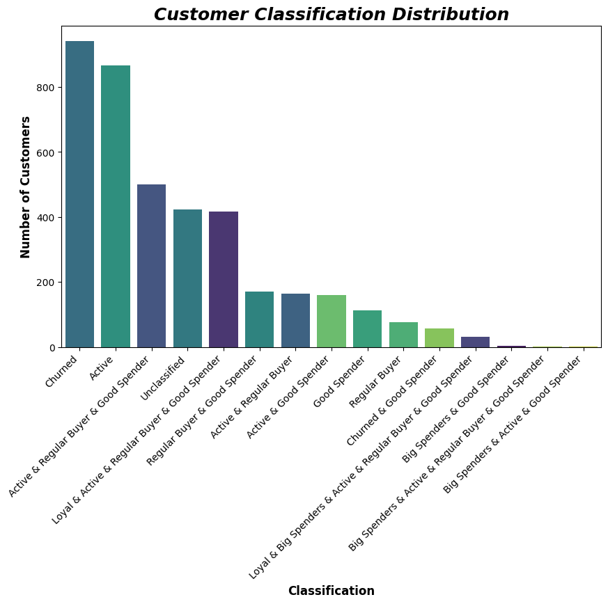

```python
plt.figure(figsize=(10, 6))
sns.countplot(
    data=rfm_classified,
    x='Classification',
    hue='Classification',
    legend=False,
    order=rfm_classified['Classification'].value_counts().index,
    palette='viridis'
)
plt.xticks(rotation=45, ha='right')
plt.title("Customer Classification Distribution", fontsize=18, fontweight='bold', style='italic')
plt.xlabel("Classification", fontsize=12, fontweight='bold')
plt.ylabel("Number of Customers", fontsize=12, fontweight='bold')
plt.show()
```

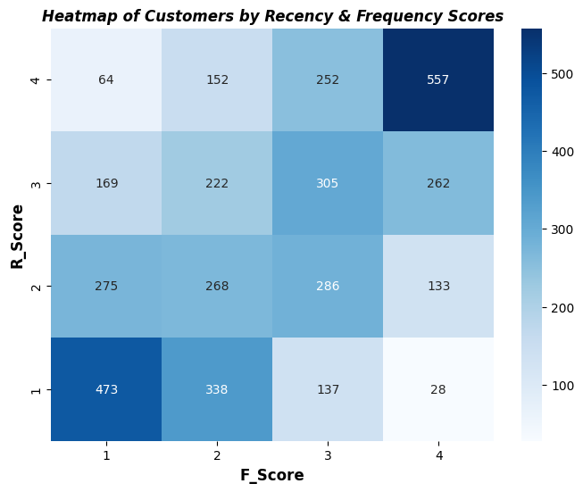

```python
# Count of customers by R and F scores
rf_counts = rfm.groupby(['R_Score', 'F_Score'], observed=True).size().reset_index(name='Count')

# Pivot for heatmap
rf_pivot = rf_counts.pivot(index='R_Score', columns='F_Score', values='Count')

plt.figure(figsize=(8, 6))
sns.heatmap(rf_pivot, annot=True, fmt='g', cmap='Blues')
plt.title("Heatmap of Customers by Recency & Frequency Scores", fontsize=12, fontweight='bold', style='italic')
plt.ylabel('R_Score', fontsize=12, fontweight='bold')
plt.xlabel('F_Score', fontsize=12, fontweight='bold')
plt.show()
```

Monetary vs. Frequency scatter (color = Recency)

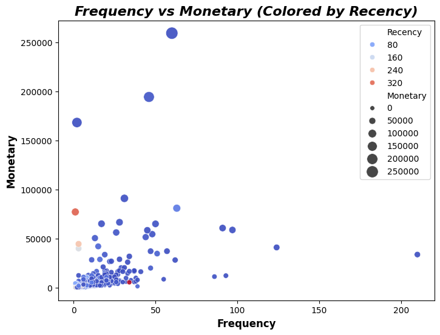

```python
plt.figure(figsize=(8, 6))
sns.scatterplot(
    data=rfm,
    x='Frequency',
    y='Monetary',
    hue='Recency',
    palette='coolwarm',
    size='Monetary',
    sizes=(30, 200),
    alpha=0.9
)
plt.title("Frequency vs Monetary (Colored by Recency)", fontsize=16, fontweight='bold', style='italic')
plt.ylabel('Monetary', fontsize=12, fontweight='bold')
plt.xlabel('Frequency', fontsize=12, fontweight='bold')
plt.show()
```